# Incognia Data Analysis

Hugo Daher

2022-03-04

# Incognia Data Analysis Report

## Introduction

Statistical analysis is an efficient way to get insights about any data, making anyone able to ask the right question. In addition, using the best technologies is crucial to get better results and faster. Therefore, this analysis used the powerful Language R to load and transform the dataset provided, creating significant visualizations with RStudio tool. Thus, this report has the result of statistical thinking that collected meaningful data to answer the right question with detailed analysis of patterns found in the data, making possible to draw conclusions that go beyond the observed data.

This report contains parts of the R code the was considered important to explain how was obtained the analysis and charts. However, the full code will be sent at the same time.

## Initial dataset schema

- event_id: identifier of the event.
- event_timestamp: event datetime in milliseconds.
- account_id: identifier of the account associated with the event.
- device: identifier of the device that performed the operation.
- distance_to_frequent_location: distance (in meters) from the device, at the time of the event, to one of the frequent locations related to the account.
- device_age_days: days since an account appeared related to a device.
- is_emulator: indicates whether the device is an emulator.
- has_fake_location: indicates whether the device was using false locations at the time of the operation.
- has_root_permissions: indicates whether the device has device administrator permissions.
- app_is_from_official_store: indicates whether or not the app used to perform the operation came from an official store.

## Dataset processing

### Loading dataset

```r
tb <- read.table("Dados/hugo_incognia_db_for_da_test.csv",
                    dec = ".",
                    sep = ",",
                    h = T,
                    fileEncoding = "windows-1252")
```

### Dataset general information

Dataset size is **444758** rows and **10** columns

### Dataset transformation

> Removing id column, not necessary for analysis

```r
tb$event_id <- NULL
```

> Shortening some column names

```r
names(tb)[4] <- "distance_fl"
names(tb)[5] <- "device_age"
names(tb)[7] <- "fake_location"
names(tb)[8] <- "root_permissions"
names(tb)[9] <- "official_store"
```

> Converting variable to integer

```r
tb$distance_fl <- as.integer(tb$distance_fl)
```

> Converting miliseconds to timestamp

```r
tb$event_timestamp <- as.POSIXct(tb$event_timestamp / 1000,
                                 origin = "1970-01-01",
                                 tz = "UTC")
```

> Creating variable Event Hour, Date and Weekday

```r
tb$event_hour <- format(tb$event_timestamp,"%H")
tb$event_hour <- as.numeric(tb$event_hour)
tb$event_date <- as.Date(tb$event_timestamp,format="%Y-%m-%d")
Sys.setlocale("LC_TIME","English")
```

```
## [1] "English_United States.1252"
```

```r
tb$weekday <- weekdays(tb$event_date)
tb$wday <- as.integer(as.POSIXlt(tb$event_date)$wday)
```

The date range of the dataset is: **2021-07-01** to **2021-07-31**

> Missing values

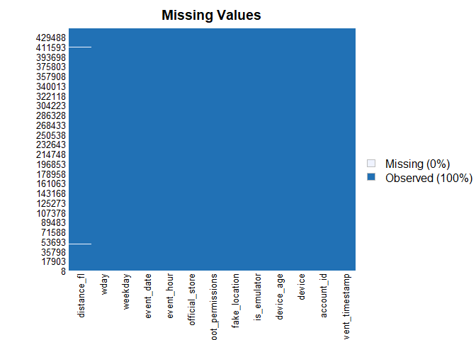

```r
Amelia::missmap(tb, main = "Missing Values")
```

There are 678 missing values. However, all missing values are in a location variable, which is crucial to determine risk because it’s a login attempt without location information. Solution was replacing **“NA”** for **-1** instead removing.

```r
tb <- tidyr::replace_na(tb, list(distance_fl = -1))
```

> Creating a Device Age Category

```r
tb$age_category <- cut(tb$device_age,
            breaks = c(0,1,7,30,365,Inf),
            labels = c("Day",
                       "Week",
                       "Month",
                       "Year",
                       "Year+"), right = FALSE)
```

> Creating a Distance to frequent location Category

```r
tb$distance_group <- cut(tb$distance_fl,
                              breaks = c(-1,0,1,10,Inf),
                              labels = c("No Location",
                                         "Freq Location",
                                         "Near FL",
                                         "Far FL"),
                         right = FALSE)
```

> Creating Risk Score variable

```r
tb$score_risk = 0
tb$score_risk <- tb$score_risk +
  ifelse(tb$event_hour>=0 & tb$event_hour<=6,1,0)
tb$score_risk <- tb$score_risk +
  ifelse(tb$distance_group=="No Location",3,0)
tb$score_risk <- tb$score_risk +
  ifelse(tb$distance_group=="Far FL",2,0)
tb$score_risk <- tb$score_risk +
  ifelse(tb$distance_group=="Near FL",1,0)
tb$score_risk <- tb$score_risk +
  ifelse(tb$age_category=="Day",1,0)
tb$score_risk <- tb$score_risk +
  ifelse(tb$is_emulator=="true",3,0)
tb$score_risk <- tb$score_risk +
  ifelse(tb$fake_location=="true",3,0)
tb$score_risk <- tb$score_risk +
  ifelse(tb$root_permissions=="true",3,0)
tb$score_risk <- tb$score_risk +
  ifelse(tb$official_store=="false",3,0)
```

> Creating Risk Level (category based on score)

```r
tb$risk_level <- cut(tb$score_risk,
                              breaks = c(0,2,3,Inf),
                              labels = c("Low",
                                         "Medium",
                                         "High"),
                     right = FALSE)
```

### Variables added to the dataset schema

- event_hour: hour of the event day.
- event_date: event date (yyyy-mm-dd)
- weekday: day of the week
- wday: number of day of the week
- age_category: variable device_age sliced in a category (**“Day”**, **“Week”**, **“Month”**, **“Year”**, **“Year+”**)
- distance_group: variable distance_fl sliced in a category (**“No Location”**, **“Freq Location”**, **“Near FL”**, **“Far FL”**)
- score_risk: variable that accumulates points whenever another variable indicates some risk
- risk_level: variable score_risk sliced in a category (**“Low”**, **“Medium”**, **“High”**)

### Graphical representation of dataset

> Heatmap to analyze correlation between variables

In this heatmap it is possible to observe that there is little or no correlation between the numerical variables.

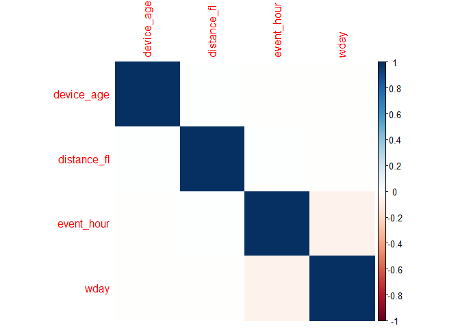

```r
M = cor(tb_num)
corrplot::corrplot(M, method = 'color', order = 'alphabet')
```

> Barplot analysis

In the bar charts below, it is possible to observe the distribution of events in the risk_level variable, in which most of the events in this dataset can be considered as low risk.

Regarding distance_to_frequent_location, the information shows that most of the events occurred in places that are not exactly at the frequent location.

About the device age category, most of the events are associated with devices aged between one month and one year.

Among the Boolean variables, there were very few contradictory cases related to suspicious behavior of the device.

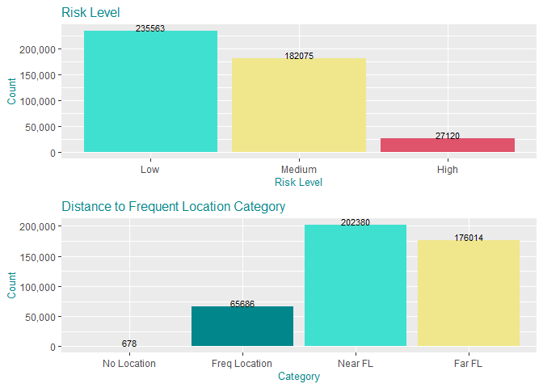

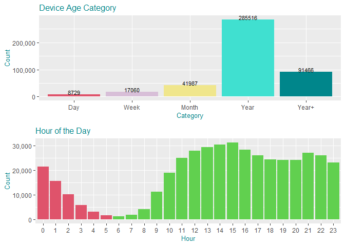

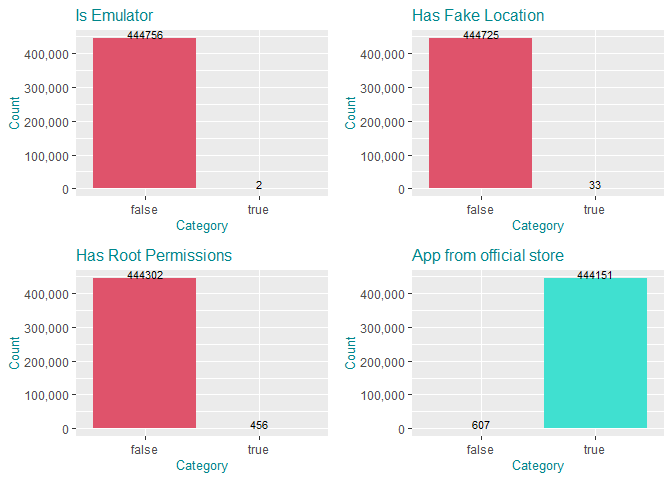

> Boxplot analysis - Numeric Variables

In the box plot diagram below, it is possible to analyze the representation of the observed data variation of the numeric variables.

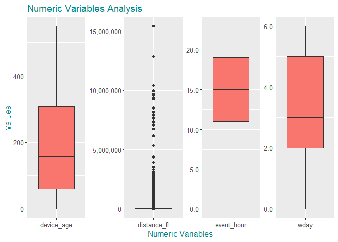

> Boxplot analysis - Boolean Variables

The box plots below show the data variation of the Boolean variables in relation to the Device Age to identify any correlation between all of them.

Moreover, in the last box plot below, there is a relationship between Device Age and Distance to Frequent Location category, showing how most of the devices with no locations available are device in the minimal age.

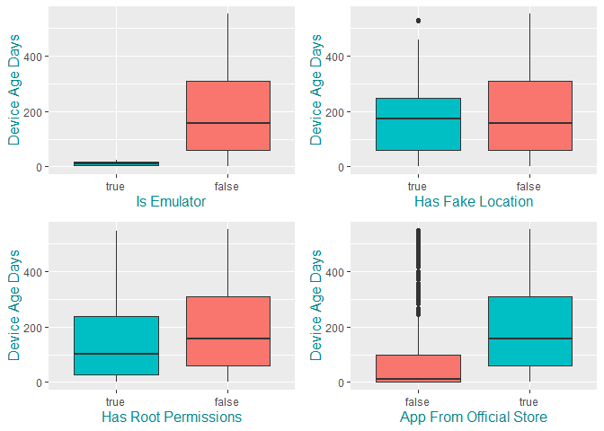

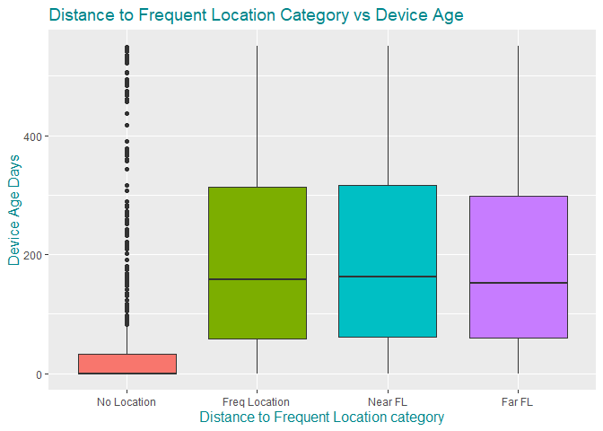

> Scatter Plot analysis

In the scatter plot below, it is easy observe the data and how scattered data is. In addition, there is little relationship between the distance from the frequent location and device age.

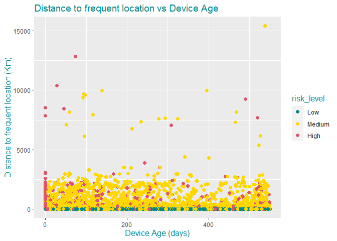

> Histogram of distribution

This histogram illustrates the distribution of events in relation to the maximum age found for each device, concluding that there are usually many more devices with a lower age.

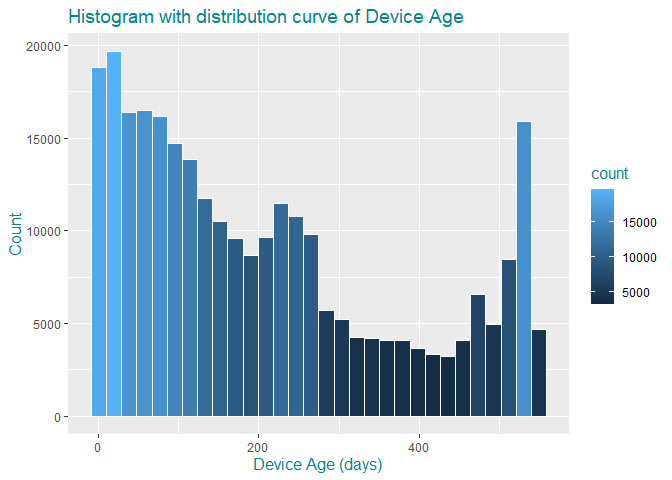

> Area chart analysis

The area chart gives a good perception of the proportionality of the risk level over the days the event occurred. According to the chart, there is no oscillation in high-risk events in relation to the day of the week, while the risk levels low and medium show oscillation on days that are weekends.  
Meanwhile, the stacked bar chart below confirms this information showing fewer events on Sundays.

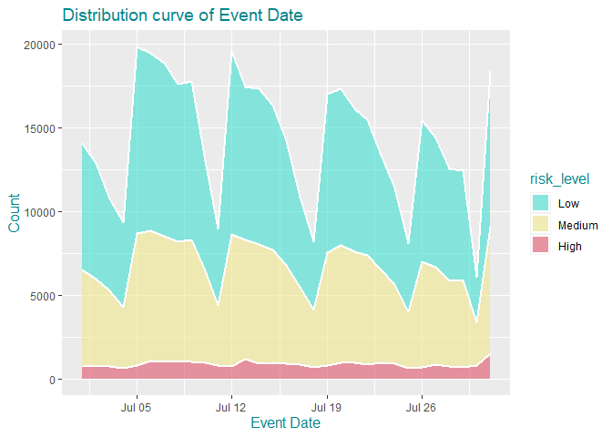

> Stacked bar chart analysis

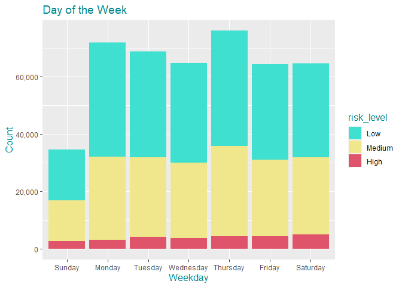

### Analysis Conclusion

The dataset analysis found patterns related to the accounts and devices that indicate suspicious behavior, possibly associated with fraud. In this report, it is possible to understand how these patterns occur and how often. Moreover, with the patterns found, it was possible to create a variable that measures risk with a score points. The higher the score, the greater the risk. In addition, another variable was defined to categorize the risk in 3 levels: **Low**, **Medium** and **High**. Thus, Incognia will be able to improve the detection algorithm and increase efficiency in the communication with the financial client in order to avoid fraud.

## Machine Learning Model

### Objective

Create a machine learning model to predict whether a financial event is a fraud event based on patterns found in a dataset.

### Preparing data to the model

> Sample random rows in dataframe

Only 3000 rows were selected at random from the dataset. More than this value requires a higher computational level.

> Sample random rows in dataframe

```r
df = data.frame(tb)
tb_ml <- df[sample(nrow(df), 3000), ]
```

```r
tb_ml$is_fraud <- ifelse(tb_ml$score_risk>=4,1,0)
```

> Selecting rows according to variable IS_FRAUD

```r
index <- createDataPartition(tb_ml$is_fraud,
                             p = 0.75,
                             list = FALSE)
```

> Setting training data as a subset

```r
data_training <- tb_ml[index,]
```

> Percentage comparison between training classes and original dataset

```r
data_comparison
```

```
##      Training Original
## 0 0.996890271    0.997
## 1 0.003109729    0.003
```

> Plot - Training vs original

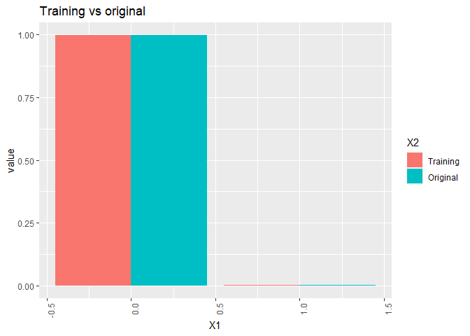

```r
ggplot(melt_data_comparison, aes(x = X1, y = value)) +
  geom_bar( aes(fill = X2),
            stat = "identity",
            position = "dodge") +
  ggtitle("Training vs original") +
  theme(axis.text.x = element_text(angle = 90, hjust = 1))
```

> Building model version 1

```r
model_v1 <- randomForest(is_fraud ~ ., data = data_training)
```

```
##
## Call:
##  randomForest(formula = is_fraud ~ ., data = data_training)
##                Type of random forest: classification
##                      Number of trees: 500
## No. of variables tried at each split: 2
##
##         OOB estimate of  error rate: 0.31%
## Confusion matrix:
##      0 1 class.error
## 0 2244 0           0
## 1    7 0           1
```

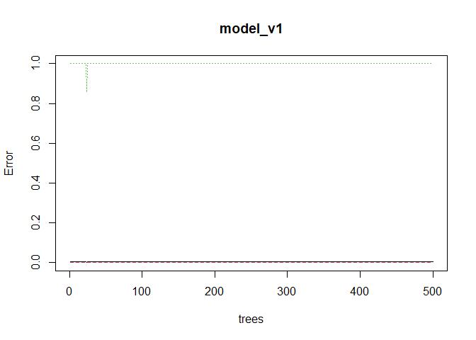

> Predicting the test dataset

```r
predict_v1 <- predict(model_v1, data_test)
```

> Confusion Matrix to calculate a cross-tabulation of observed and predicted classes

```r
cm_v1
```

```
## Confusion Matrix and Statistics
##
##           Reference
## Prediction   0   1
##          0 747   2
##          1   0   0
##
##                Accuracy : 0.9973
##                  95% CI : (0.9904, 0.9997)
##     No Information Rate : 0.9973
##     P-Value [Acc > NIR] : 0.6767
##
##                   Kappa : 0
##
##  Mcnemar's Test P-Value : 0.4795
##
##             Sensitivity : 0.00000
##             Specificity : 1.00000
##          Pos Pred Value :     NaN
##          Neg Pred Value : 0.99733
##              Prevalence : 0.00267
##          Detection Rate : 0.00000
##    Detection Prevalence : 0.00000
##       Balanced Accuracy : 0.50000
##
##        'Positive' Class : 1
##
```

> Precision, Recall e F1-Score, measures to evaluate predict model

```r
y <- data_test$is_fraud
y_pred_v1 <- predict_v1

precision <- posPredValue(y_pred_v1, y)
recall <- sensitivity(y_pred_v1, y)
F1 <- (2 * precision * recall) / (precision + recall)

df2 <- data.frame(precision,recall,F1)
names(df2) <- c("Precision","Recall","F1")
df2
```

```
##   Precision Recall        F1
## 1 0.9973298      1 0.9986631
```

> SMOTE algorithm for unbalanced classification problems

```r
set.seed(9560)
data_training_bal <- SMOTE(is_fraud ~ .,
                           data  = data_training)
```

> Building model version 2

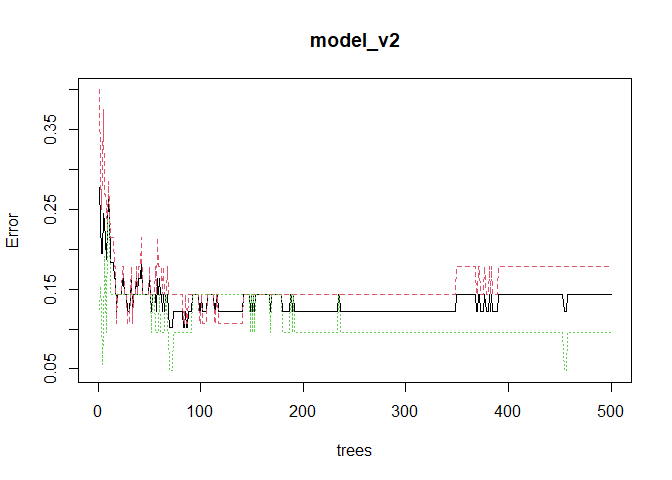

```r
plot(model_v2)
```

> Predicting the test dataset

```r
predict_v2 <- predict(model_v2, data_test)
```

> Confusion Matrix

```r
cm_v2
```

```
## Confusion Matrix and Statistics
##
##           Reference
## Prediction   0   1
##          0 680   1
##          1  67   1
##
##                Accuracy : 0.9092
##                  95% CI : (0.8863, 0.9288)
##     No Information Rate : 0.9973
##     P-Value [Acc > NIR] : 1
##
##                   Kappa : 0.0235
##
##  Mcnemar's Test P-Value : 3.211e-15
##
##             Sensitivity : 0.500000
##             Specificity : 0.910308
##          Pos Pred Value : 0.014706
##          Neg Pred Value : 0.998532
##              Prevalence : 0.002670
##          Detection Rate : 0.001335
##    Detection Prevalence : 0.090788
##       Balanced Accuracy : 0.705154
##
##        'Positive' Class : 1
##
```

> Precision, Recall e F1-Score

```r
y <- data_test$is_fraud
y_pred_v2 <- predict_v2

precision <- posPredValue(y_pred_v2, y)
recall <- sensitivity(y_pred_v2, y)
F1 <- (2 * precision * recall) / (precision + recall)

df3 <- data.frame(precision,recall,F1)
names(df3) <- c("Precision","Recall","F1")
df3
```

```
##   Precision    Recall       F1
## 1 0.9985316 0.9103079 0.952381
```

> Most important variables to predict

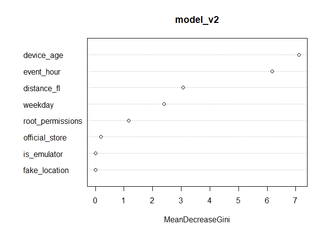

```r
varImpPlot(model_v2)
```

> Ranking of the most important variables

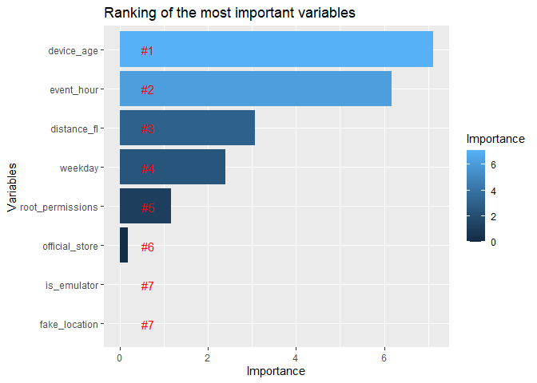

> Building model version 3 with the most important variables

```r
model_v3 <- randomForest(is_fraud ~ device_age +
                           event_hour +
                           distance_fl +
                           weekday +
                           official_store +
                           root_permissions,
                          data = data_training_bal)
```

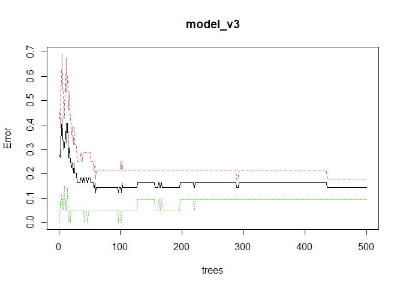

```r
plot(model_v3)
```

> Predicting the test dataset

```r
predict_v3 <- predict(model_v3, data_test)
```

> Confusion Matrix

```r
cm_v3
```

```
## Confusion Matrix and Statistics
##
##           Reference
## Prediction   0   1
##          0 647   1
##          1 100   1
##
##                Accuracy : 0.8652
##                  95% CI : (0.8386, 0.8888)
##     No Information Rate : 0.9973
##     P-Value [Acc > NIR] : 1
##
##                   Kappa : 0.0143
##
##  Mcnemar's Test P-Value : <2e-16
##
##             Sensitivity : 0.500000
##             Specificity : 0.866131
##          Pos Pred Value : 0.009901
##          Neg Pred Value : 0.998457
##              Prevalence : 0.002670
##          Detection Rate : 0.001335
##    Detection Prevalence : 0.134846
##       Balanced Accuracy : 0.683066
##
##        'Positive' Class : 1
##
```

> Precision, Recall e F1-Score

```r
y <- data_test$is_fraud
y_pred_v3 <- predict_v3

precision <- posPredValue(y_pred_v3, y)
recall <- sensitivity(y_pred_v3, y)
F1 <- (2 * precision * recall) / (precision + recall)
df4 <- data.frame(precision,recall,F1)
names(df4) <- c("Precision","Recall","F1")
df4
```

```
##   Precision    Recall        F1
## 1 0.9984568 0.8661312 0.9275986
```

> Salving model file

```r
rds <- paste("Dados/",
             format(Sys.time(), "%y%m%d%H%M%S"),
             "_model_v3.rds",sep = "")
saveRDS(model_v3, file = rds)
```

> Predicting three random events

```r
# Input
device_age <- c(0, 10, 100)
event_hour <- c("4", "10", "11")
distance_fl <- c(1000, 1, 0)
weekday <- c("Sunday","Sunday","Sunday")
official_store <- c("true","true","true")
root_permissions <- c("false","false","false")
```

> Predictions results

```r
pred_new_events <- predict(model_v3, new_events)
pred = data.frame(pred_new_events)
pred$is_fraud <- ifelse(pred_new_events==0,"No","Yes")
pred
```

```
##   pred_new_events is_fraud
## 1               1      Yes
## 2               0       No
## 3               1      Yes
```

### Model Results

To create a machine learning model, it would be important to have a sample with descriptive information determining whether each event is a fraud event. With this information, it would be possible to create a prediction algorithm model to predict which future events will be a fraud event based on the training and testing model.

However, the dataset provided did not contain the information about fraud (if was a fraud - yes/no), then a risk score was suggested based on the patterns found in the preliminary analysis. Thus, based on the **hypothesis** that a risk score of 4+ is a **fraud event**, a machine learning model was developed to predict future events.

However, it is important having more data about de event, such as *“distance to frequent location is inside or outside a building”*. In addition, having rules defined about *“risk level”* is exactly the main point to make a efficient algorithm and do the right recommendations to the client, but for this analysis, the recommendation is based on the variables that was considered important to the case analysis.

### Additional Observations

According to recent research, it is a tendency to use some business intelligence tools to improve visualizations and to interact with the charts and tables. Because this, a Microsoft Power BI dashboard was developed in addition by using as a source the dataset regenerated in this analysis. Thus, the Power BI file (pbix) will be sent as part of this analysis to observe how data interact between charts.

### Related Links

1. Link to this report on RPubs: [link](https://rpubs.com/hugodaher/incognia_v3)
2. Link to this report on GitHub: [link](https://hrmd.github.io/IncogniaDA/Incognia_DA_v2.html)
3. Link to the codes on GitHub: [link](https://github.com/hrmd/IncogniaDA/blob/main/Case_Tecnico_R.R)
4. Link to Power BI dashboard: [link](https://app.powerbi.com/view?r=eyJrIjoiM2Q4NTJlZDYtN2UwMC00Yzg1LWI1ZDQtNmQ2NjVjOTQ0NWEyIiwidCI6IjQzNzZmOTA2LWI1NWYtNDY5Yi1iNTU1LTRkNzUzMTQ2ODE4YiJ9&pageName=ReportSection99245ef3b30b890dc80e)